# Fantasy Football Weekly Recap

[figure not shown]

[figure not shown]

[figure not shown]

[figure not shown]

[figure not shown]

[figure not shown]

[figure not shown]

[figure not shown]

[figure not shown]

[figure not shown]

[figure not shown]

# Im so Hardman vs. Very Unfourtunette

### Game Summary

Im so Hardman vs. Very Unfourtunette

| 109.94 | 92.5 |
| --- | --- |

### Scoring Timeline

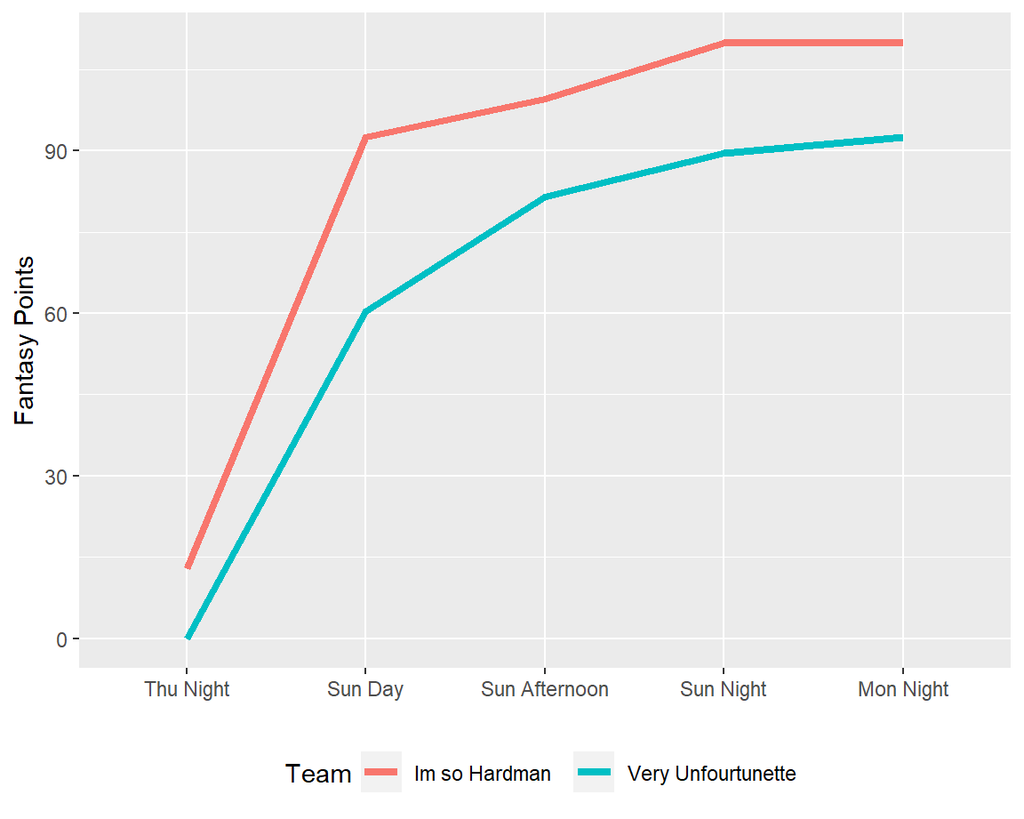

### Points by Position

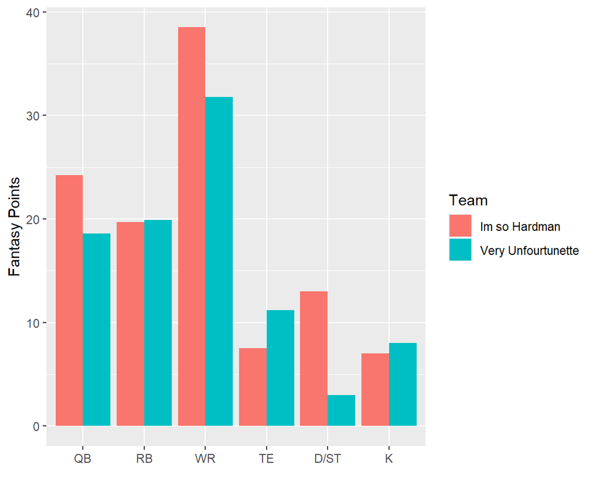

### Top Scorers

| Very Unfourtunette Player | Very Unfourtunette FPTS | Im so Hardman Player | Im so Hardman FPTS |
| --- | --- | --- | --- |
| Lamar Jackson | 18.6 | Deshaun Watson | 24.24 |
| Julio Jones | 16.4 | A.J. Brown | 20.10 |
| James Robinson | 15.9 | Giants D/ST | 13.00 |

### Optimized Lineups

SLOT

Im so Hardman

FPTS

Very Unfourtunette

FPTS

QB

Ben Roethlisberger

25.04

Matt Ryan

22.36

RB

Derrick Henry

6.80

James Robinson

15.90

RB

Aaron Jones

12.90

J.D. McKissic

17.20

WR

A.J. Brown

20.10

Julio Jones

16.40

WR

Terry McLaurin

24.50

Justin Jefferson

9.40

TE

Noah Fant

7.50

Eric Ebron

11.20

FLEX

Mike Evans

10.40

Leonard Fournette

10.10

Daniel Carlson

7.00

Wil Lutz

8.00

Giants D/ST

13.00

Patriots D/ST

3.00

Total

127.24

113.56

### Lowest Scorers

| Very Unfourtunette Player | Very Unfourtunette FPTS | Im so Hardman Player | Im so Hardman FPTS |
| --- | --- | --- | --- |
| Patriots D/ST | 3 | Derrick Henry | 6.8 |
| James Conner | 4 | Daniel Carlson | 7.0 |
| DeAndre Hopkins | 6 | Noah Fant | 7.5 |

# Alvin And The Chipmunks vs. Welcome to the Dak Side

### Game Summary

Alvin And The Chipmunks vs. Welcome to the Dak Side

| 133.8 | 85.9 |
| --- | --- |

### Scoring Timeline

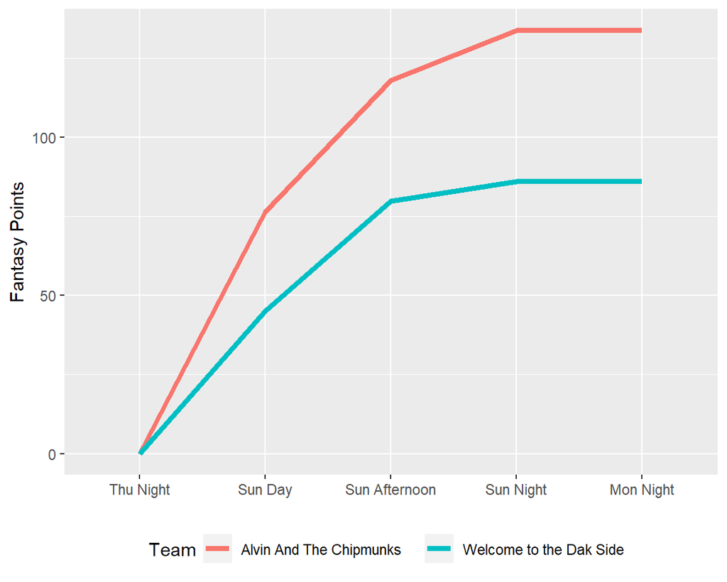

### Points by Position

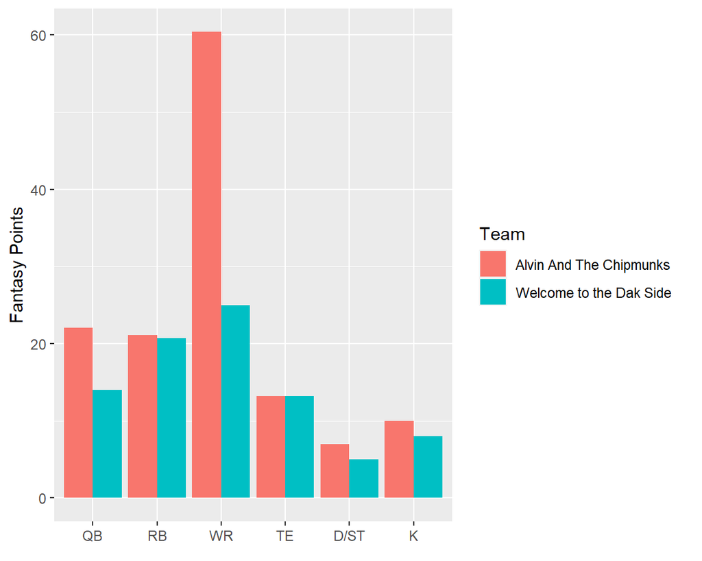

### Top Scorers

| Welcome to the Dak Side Player | Welcome to the Dak Side FPTS | Alvin And The Chipmunks Player | Alvin And The Chipmunks FPTS |
| --- | --- | --- | --- |
| Allen Robinson II | 15.1 | DK Metcalf | 23.8 |
| Derek Carr | 14.0 | Russell Wilson | 22.1 |
| Hayden Hurst | 13.2 | JuJu Smith-Schuster | 21.3 |

### Optimized Lineups

SLOT

Alvin And The Chipmunks

FPTS

Welcome to the Dak Side

FPTS

QB

Russell Wilson

22.10

Derek Carr

14.0

RB

Alvin Kamara

15.90

Chase Edmonds

11.8

RB

David Montgomery

5.20

Zack Moss

12.8

WR

DK Metcalf

23.80

Allen Robinson II

15.1

WR

JuJu Smith-Schuster

21.30

DJ Chark Jr.

27.6

TE

T.J. Hockenson

14.90

Hayden Hurst

13.2

FLEX

CeeDee Lamb

15.34

DeVante Parker

12.4

Harrison Butker

10.00

Matt Prater

8.0

Bills D/ST

12.00

Washington D/ST

5.0

Total

140.54

119.9

### Lowest Scorers

| Welcome to the Dak Side Player | Welcome to the Dak Side FPTS | Alvin And The Chipmunks Player | Alvin And The Chipmunks FPTS |
| --- | --- | --- | --- |
| DJ Moore | 3.8 | David Montgomery | 5.2 |
| Washington D/ST | 5.0 | Steelers D/ST | 7.0 |
| Antonio Brown | 6.1 | Harrison Butker | 10.0 |

# Porkin Popps Sister vs. We Love TDs

### Game Summary

Porkin Popps Sister vs. We Love TDs

| 141.22 | 112.56 |
| --- | --- |

### Scoring Timeline

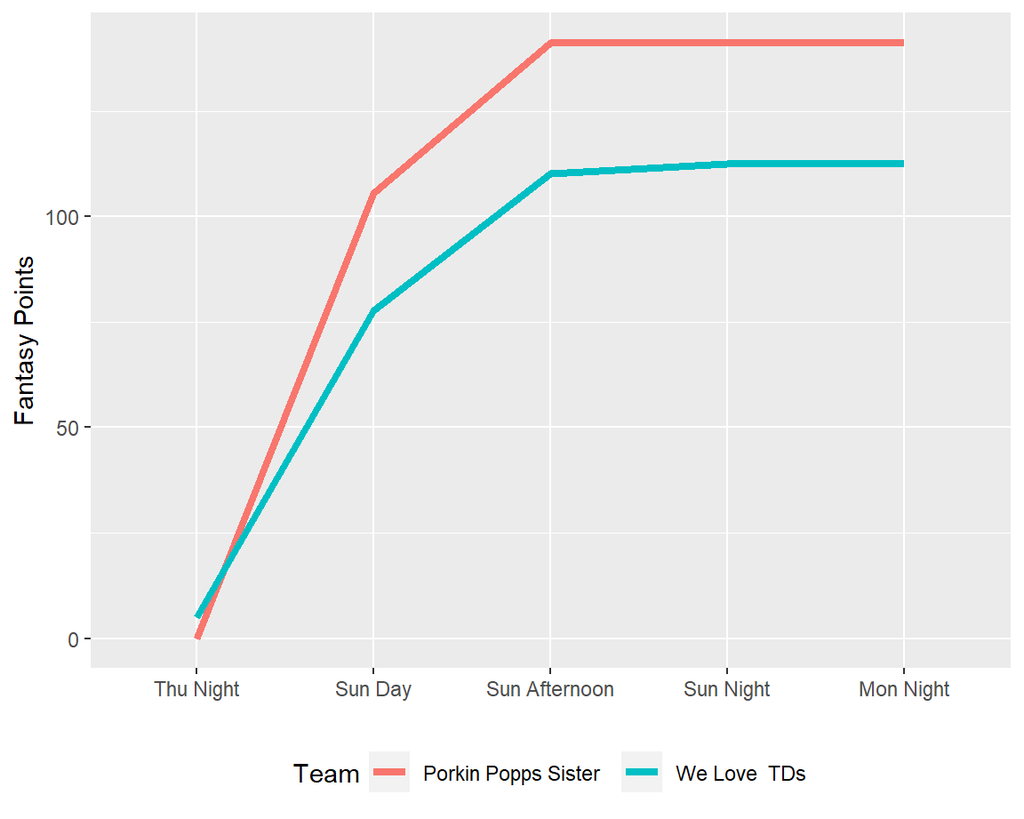

### Points by Position

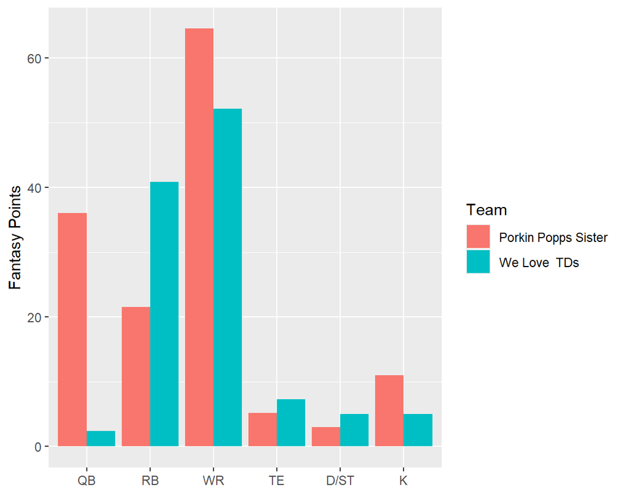

### Top Scorers

| We Love TDs Player | We Love TDs FPTS | Porkin Popps Sister Player | Porkin Popps Sister FPTS |
| --- | --- | --- | --- |
| Christian McCaffrey | 37.1 | Josh Allen | 36.0 |
| Keenan Allen | 25.3 | Tyreek Hill | 33.1 |
| Will Fuller V | 21.0 | Brandin Cooks | 17.3 |

### Optimized Lineups

SLOT

Porkin Popps Sister

FPTS

We Love TDs

FPTS

QB

Kyler Murray

37.92

Aaron Rodgers

28.9

RB

Josh Jacobs

13.80

Christian McCaffrey

37.1

RB

Tony Pollard

7.72

Melvin Gordon III

3.7

WR

Tyreek Hill

33.10

Will Fuller V

21.0

WR

Brandin Cooks

17.30

Keenan Allen

25.3

TE

Jonnu Smith

11.20

Hunter Henry

7.3

FLEX

Diontae Johnson

14.10

Marvin Jones Jr.

13.3

Brandon McManus

11.00

Robbie Gould

5.0

Falcons D/ST

3.00

Colts D/ST

5.0

Total

149.14

146.6

### Lowest Scorers

| We Love TDs Player | We Love TDs FPTS | Porkin Popps Sister Player | Porkin Popps Sister FPTS |
| --- | --- | --- | --- |
| Tom Brady | 2.36 | Falcons D/ST | 3.00 |
| Melvin Gordon III | 3.70 | Mark Andrews | 5.20 |
| Colts D/ST | 5.00 | Tony Pollard | 7.72 |

# Adams (Hughes) Bomb vs. Slant Boys

### Game Summary

Adams (Hughes) Bomb vs. Slant Boys

| 108.54 | 118.58 |
| --- | --- |

### Scoring Timeline

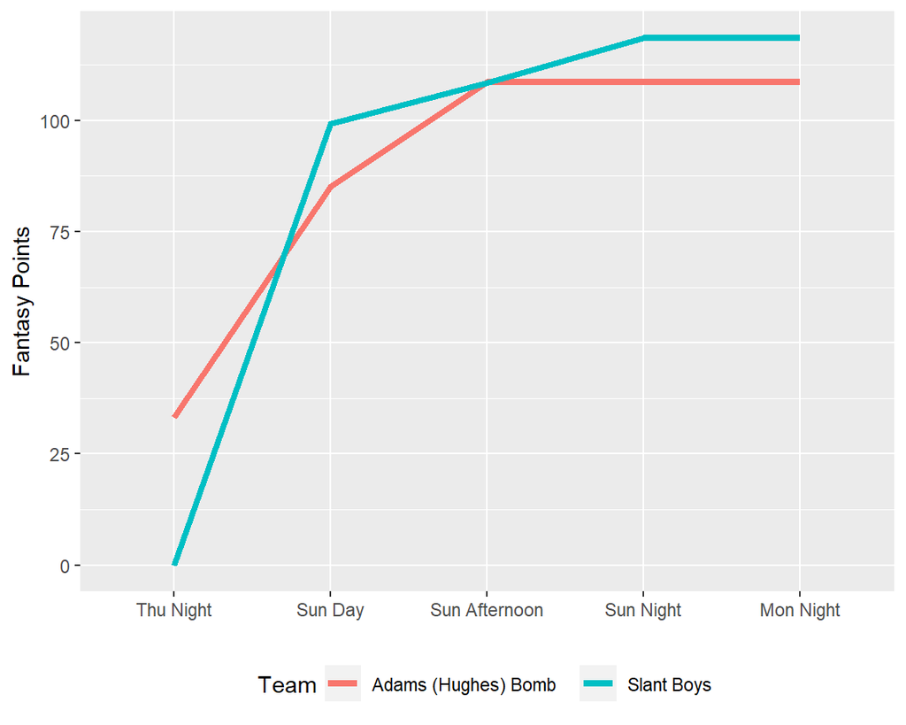

### Points by Position

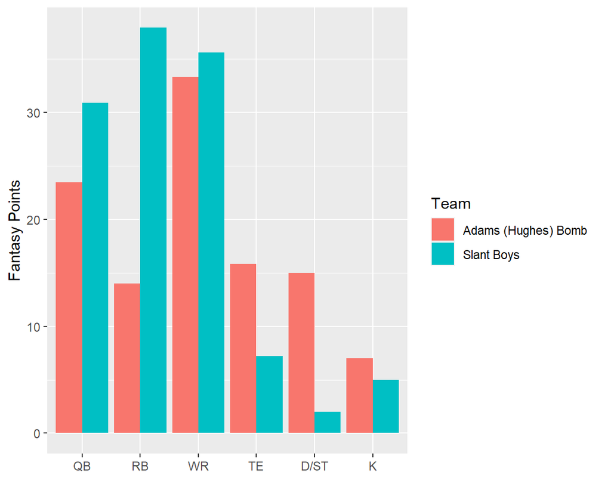

### Top Scorers

| Slant Boys Player | Slant Boys FPTS | Adams (Hughes) Bomb Player | Adams (Hughes) Bomb FPTS |
| --- | --- | --- | --- |
| Patrick Mahomes | 30.88 | Davante Adams | 33.30 |
| Jerry Jeudy | 25.50 | Justin Herbert | 23.44 |
| Todd Gurley II | 13.50 | Evan Engram | 15.80 |

### Optimized Lineups

SLOT

Adams (Hughes) Bomb

FPTS

Slant Boys

FPTS

QB

Justin Herbert

23.44

Patrick Mahomes

30.88

RB

Clyde Edwards-Helaire

12.40

Todd Gurley II

13.50

RB

D’Andre Swift

12.70

Antonio Gibson

12.50

WR

Davante Adams

33.30

Michael Thomas

10.10

WR

Jamison Crowder

10.60

Jerry Jeudy

25.50

TE

Evan Engram

15.80

Mike Gesicki

7.20

FLEX

David Johnson

1.60

DeeJay Dallas

11.90

Justin Tucker

7.00

Rodrigo Blankenship

5.00

Ravens D/ST

15.00

Cardinals D/ST

2.00

Total

131.84

118.58

### Lowest Scorers

| Slant Boys Player | Slant Boys FPTS | Adams (Hughes) Bomb Player | Adams (Hughes) Bomb FPTS |
| --- | --- | --- | --- |
| Cardinals D/ST | 2.0 | Justin Jackson | 0.0 |
| Rodrigo Blankenship | 5.0 | Corey Davis | 0.0 |
| Mike Gesicki | 7.2 | David Johnson | 1.6 |

# Kupp These Nuts vs. The Practice Squad

### Game Summary

Kupp These Nuts vs. The Practice Squad

| 123.26 | 139.36 |
| --- | --- |

### Scoring Timeline

[figure not shown]

### Points by Position

[figure not shown]

### Top Scorers

| The Practice Squad Player | The Practice Squad FPTS | Kupp These Nuts Player | Kupp These Nuts FPTS |
| --- | --- | --- | --- |
| Travis Kelce | 25.90 | Dalvin Cook | 39.20 |
| Christian Kirk | 23.14 | Cam Newton | 24.56 |
| Stefon Diggs | 20.80 | Chase Claypool | 15.30 |

### Optimized Lineups

SLOT

Kupp These Nuts

FPTS

The Practice Squad

FPTS

QB

Cam Newton

24.56

Drew Brees

22.68

RB

Dalvin Cook

39.20

Jerick McKinnon

17.00

RB

Joshua Kelley

10.90

WR

Mike Williams

13.10

Stefon Diggs

20.80

WR

Chase Claypool

15.30

Christian Kirk

23.14

TE

Rob Gronkowski

1.20

Travis Kelce

25.90

FLEX

Amari Cooper

12.50

Younghoe Koo

12.00

Mason Crosby

12.00

Texans D/ST

4.00

Bears D/ST

4.00

Total

131.16

155.02

### Lowest Scorers

[output not shown]

# League Statistics

### Points by Week

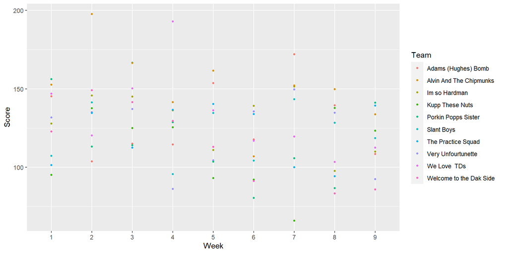

# Playoffs

### Playoff Picture

| RK | Team | W | L | GB | PF | PA | STRK |
| --- | --- | --- | --- | --- | --- | --- | --- |
| 1 | Alvin And The Chipmunks | 8 | 1 | 0 | 1362.64 | 1002.30 | W5 |
| 2 | Im so Hardman | 7 | 2 | 1 | 1164.34 | 1046.30 | W4 |
| 3 | Slant Boys | 6 | 3 | 2 | 1140.06 | 1097.68 | W1 |
| 4 | The Practice Squad | 5 | 4 | 3 | 1093.10 | 1124.88 | W2 |
| 5 | Adams (Hughes) Bomb | 4 | 5 | 4 | 1169.90 | 1236.08 | L1 |
| 6 | We Love TDs | 3 | 6 | 5 | 1198.94 | 1234.70 | L5 |
| 7 | Very Unfourtunette | 3 | 6 | 5 | 1107.00 | 1182.64 | L1 |
| 8 | Welcome to the Dak Side | 3 | 6 | 5 | 1035.94 | 1086.68 | L4 |
| 9 | Porkin Popps Sister | 3 | 6 | 5 | 1029.60 | 1096.62 | W1 |
| 10 | Kupp These Nuts | 3 | 6 | 5 | 995.50 | 1189.14 | L3 |

### Playoff Probabilities

| RK | Team | ExpWins | ExpLosses | Playoffs | Bye |
| --- | --- | --- | --- | --- | --- |
| 1 | Alvin And The Chipmunks | 11.0 | 2.0 | 1.000 | 0.984 |
| 2 | Im so Hardman | 9.9 | 3.1 | 1.000 | 0.892 |
| 3 | Slant Boys | 9.0 | 4.0 | 1.000 | 0.123 |
| 4 | The Practice Squad | 7.0 | 6.0 | 0.980 | 0.001 |
| 5 | Adams (Hughes) Bomb | 5.5 | 7.5 | 0.758 | 0.000 |
| 6 | Very Unfourtunette | 4.7 | 8.3 | 0.343 | 0.000 |
| 7 | Kupp These Nuts | 4.7 | 8.3 | 0.178 | 0.000 |
| 8 | Welcome to the Dak Side | 4.6 | 8.4 | 0.269 | 0.000 |
| 9 | Porkin Popps Sister | 4.4 | 8.6 | 0.129 | 0.000 |
| 10 | We Love TDs | 4.3 | 8.7 | 0.343 | 0.000 |